# Homework 7: Prediction III

STA 235H

Due on Dec. 1st, 11:59pm

# Note

- This document will serve as your Answer Key for Homework 7. Please check the rubric to understand how the assignment is graded.
- All automatically-graded questions will receive full credit if correct or 0 points if they are not correct. The only exception is with multiple answers were points are allocated proportionally.
- Inconsistencies between code and answers will be discounted (i.e. if an answer is correct, but the code used to get to that answer is not, that question will be discounted).
- R scripts and PDF files will also be checked for completeness. If they are not complete (i.e. do not contain the code/output requested), a discount will apply.
- After you receive your graded assignment, you will have one week to submit re-grading requests. Please compare your graded submission with this answer key and fill out the re-grading form with your specific request.

# Task 1 - Conceptual Questions

**1.1) Assess the following statement:**

“Using a model selection approach (for selecting predictors) helps reduce bias in our prediction model”.

Answer:

FALSE

**1.2) Regarding random forests, which of the following statements is/are TRUE?**

1. The main objective in random forests is reducing variance.
2. In random forests, we don’t need to create a training dataset because we will bootstrap different samples for each tree
3. Every tree will use a different set of predictors
4. We can fit as many trees as we want without the risk of overfitting our model.

Answer:

A and D

**1.3) According to the material we have seen in class and the readings that you have had to do, which of the following statements is/are FALSE?**

1. If we increase the complexity of a model, the RMSE in the training dataset will most likely decrease.
2. In boosting, just like in random forests or bagging, the number of trees is not a tuning parameter.
3. In prediction, we usually prefer a model with lower variance over lower bias.
4. Random forests generally works better than bagging because we randomly select features we use for prediction in each split.

Answer:

B and C

**1.4) What is/are the main advantage(s) of lasso over a full linear model (LM)?**

1. Lasso increases bias in our model compared to LM.
2. Lasso reduces bias by shrinking the sum of the absolute value of coefficients.
3. Generally, lasso doesn’t use all predictors in the dataset, reducing variance.
4. There are no clear advantages of lasso over a full linear model (LM)

Answer:

C

# Task 2: I want to ride my… bicycle, bicycle!

The year is 2024, and you are working for bike share company, and are in charge of operations. This means that for each day, you need to make sure there are enough bikes to satisfy demand. Right now, you predecessor set up a very simple algorithm, were each day you put the average number of bikes that were used that same month in the previous year. For example, for April 2nd, you will put out the average number of bikes that were used in April 2023.

You realize that you might be able to do things better, so you ask for some historic data, and they provide this dataset for the years 2022 and 2023:

```r
bike <- read.csv("https://raw.githubusercontent.com/maibennett/sta235/main/exampleSite/content/Assignments/Homework/HW7/data/bike_daily.csv")
```

You can find the codebook here

Your objective is to find a better prediction model for demand (`cnt`), and show how this is better from the current status quo.

Note: For any cross-validation task, use 10-fold cross-validation, and set a seed of 120. Remember to set a seed before every line of code where you run something random.

**2.1) Let’s start cleaning our data and setting up everything before fitting prediction models. For simplicity, drop `instant`, `dteday`, and `workingday` from the dataset, because we won’t be using them as predictors. Transform `season`, `weekday`, and `weathersit` to categorical variables, making sure you include the appropriate labels (this will make it easier to identify them when fitting models). Finally, create a variable called `prop_registered`, which should capture the proportion of total rides that are made by registered users. After creating the variable, drop `casual` and `registered` as well. Show your code here:** (5 points)

*Note: In this dataset, the first day of the week is Sunday*

Answer:

```r
bike <- bike %>% mutate(prop_registered = registered/cnt,
                        season = factor(season, labels = c("Spring","Summer","Fall","Winter"), levels = 1:4),
                        weekday = factor(weekday, labels = c("Sun","Mon","Tue","Wed","Thur","Fri","Sat"), levels = 0:6),
                        weathersit = factor(weathersit, labels = c("Great","Fine","Bad","Terrible"), levels = 1:4)) %>%
  select(-c(instant, dteday, casual, registered, workingday))
```

- 5 points: (i) drops appropriate variables, (ii) transforms season, weekday, and weathersit correctly, and (iii) creates prop_registered.
- 3 points: One of the previous items is not correct.
- 1 point: Two of the previous items are not correct.
- 0 points: Any other case.

**2.2) Now, let’s create a training and a testing dataset. Use a 75%-25% split, using the `initial_split()` function we saw in class, and stratifying by the outcome of interest. What is the mean of the outcome in your testing dataset?** (2 points)

Answer:

```r
library(rsample)

set.seed(120)

split <- initial_split(bike, prop = 0.75, strata = "cnt")

train.data <- training(split)
test.data <- testing(split)

round(mean(test.data$cnt), 2)
```

```
## [1] 4526.34
```

**2.3a) Let’s start building a simple linear model. Using forward stepwise selection, build a linear model and predict the total count of rental bikes (name the predicted values `pred_fwdlm`). Show your code here:** (5 points)

Answer:

```r
library(modelr)

lm.all <- lm(cnt ~ ., data = train.data)
nvars <- length(lm.all$coefficients) - 1

train.control <- trainControl(method = "cv", number = 10)

set.seed(120)

lm.fwd <- train(cnt ~ ., data = train.data,
                method = "leapForward",
                tuneGrid = data.frame(nvmax = 1:nvars),
                trControl = train.control)
```

[output not shown]

```r
pred_fwdlm = lm.fwd %>% predict(test.data)
```

- 5 points: (i) uses correct number of coefficients, (ii) runs the correct model, and (iii) creates correct predictions
- 3 points: One of the previous items is not correct.
- 1 point: Two of the previous items are not correct.
- 0 points: Any other case.

**2.3b) How many predictors are selected in 2.3a)?** (3 points)

Answer:

```r
lm.fwd$bestTune
```

|  | nvmax |
| --- | --- |
| 19 | 19 |

**2.3c) What is the pertinent metric of performance of the previous model?** (3 points)

Answer:

```r
round(rmse(lm.fwd, test.data), 2)
```

```
## [1] 764.18
```

**2.4a) Let’s compare this now to bagging. Fit 150 trees using bagging, save your predicted values in `pred_bt`, and include your code here:** (5 points)

Answer:

```r
library(rpart)

set.seed(120)

bt <- train(cnt ~ ., data = train.data,
            method = "treebag",
            trControl = train.control,
            nbagg = 150,
            control = rpart.control(cp = 0))

pred_bt = bt %>% predict(test.data)
```

- 5 points: (i) uses correct number of trees, (ii) runs the correct model, and (iii) creates correct predictions
- 3 points: One of the previous items is not correct.
- 1 point: Two of the previous items are not correct.
- 0 points: Any other case.

**2.4b) Create a plot for the importance of the predictors. Include the code and image here:** (3 points)

Answer:

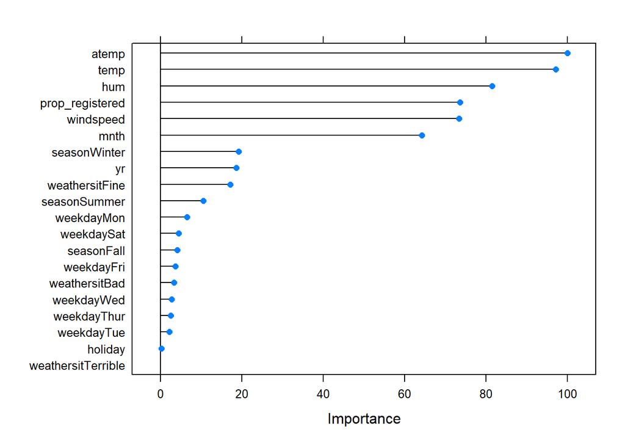

```r
plot(varImp(bt, scale = TRUE))
```

**2.4c) What is the *least* important variable in your model out of all your predictors?:** (2 points)

Answer:

In this case, the least important predictor is terrible weather.

**2.4d) What is the pertinent metric of performance of the previous model?** (3 points)

Answer:

```r
round(rmse(bt, test.data), 2)
```

```
## [1] 667.24
```

**2.5a) Let’s try a final prediction model, fitting a random forest of 150 trees. As seen in class, you can keep the split rule and minimum node side constant using the values we saw in class, and only tune for the number of randomly chosen predictors. Save your predicted values in `pred_rf`** (7 points)

*Note: In the same way you set the number of trees for bagging, you can set them up for random forests using `num.trees`*

Answer:

```r
tuneGrid <- expand.grid(
  mtry = 1:nvars,
  splitrule = "variance",
  min.node.size = 5
)

set.seed(120)

rf <- train(cnt ~ ., data = train.data,
            method = "ranger",
            num.trees = 150,
            trControl = train.control,
            importance = "permutation",
            tuneGrid = tuneGrid)

pred_rf <- rf %>% predict(test.data)
```

- 7 points: (i) uses correct number of trees, (ii) uses the right number of covariates, (iii) runs the correct model, and (iv) creates correct predictions
- 5 points: One of the previous items is not correct.
- 3 point: Two of the previous items are not correct.
- 0 points: Any other case.

**2.5b) What is the optimal number of predictors that are randomly chosen?** (3 points)

Answer:

```r
rf$bestTune$mtry
```

```
## [1] 9
```

**2.5c) What is the most important variable in your random forest model?** *Note: Use the name provided in the dataset* (2 points)

Answer:

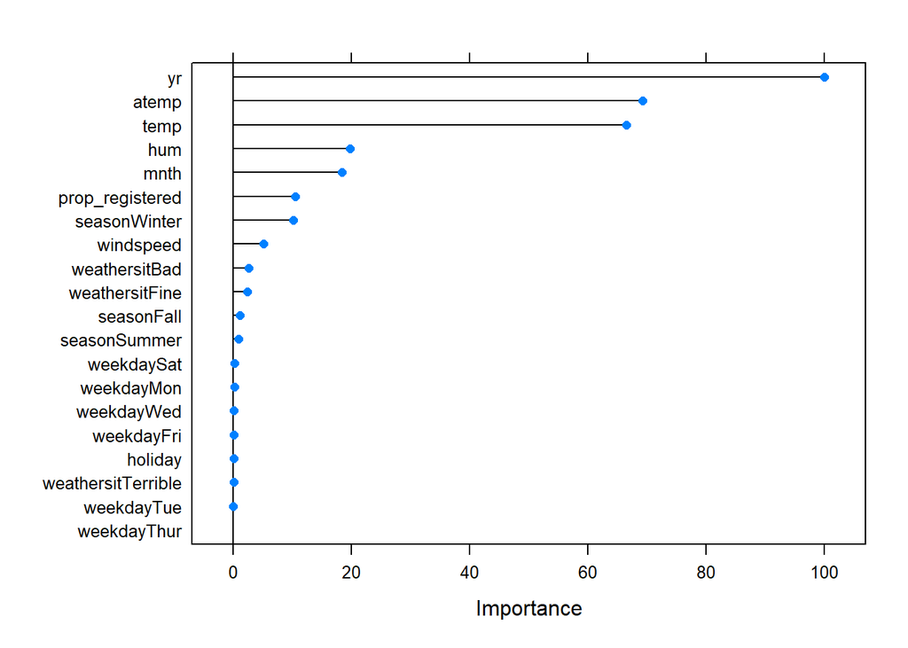

```r
plot(varImp(rf, scale = TRUE))
```

The most important variable for prediction in RF is `yr`.

**2.5d) What is the pertinent metric of performance of the previous model?** (2 points)

Answer:

```r
round(rmse(rf, test.data), 2)
```

```
## [1] 615.03
```

**2.6) Out of the three models you tested, which one would you choose?** (2 points)

1. Stepwise linear model
2. Bagged trees
3. Random Forest

Answer:

Random Forest

**2.7) Finally, let’s look at the performance! Create a density histogram of the outcome in your testing dataset, and include a density line (`geom_density`) for each of the predictors we made previously. In order to do this, you can add the previous predictions (`pred_fwdlm`, `pred_bt`, and `pred_rf`) as new variables in your testing dataset. Show your code and a clear image of your plot here:** (10 points)

*To create a density histogram, you will need to use `geom_histogram(aes(y = ..density..))` to the ggplot that you don’t want the frequency in the Y axis, but density values.*

Answer:

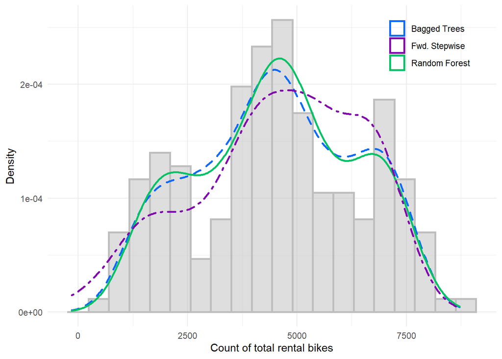

```r
test.data <- test.data %>% mutate(pred.lmfwd = pred_fwdlm,
                                  pred.bt = pred_bt,
                                  pred.rf = pred_rf)

ggplot(data = test.data, aes(x = cnt)) +
  geom_histogram(aes(y = ..density..), color = "grey", fill = alpha("grey", 0.5), lwd = 1, bins = 20) +
  geom_density(aes(x = pred.bt, color = "Bagged Trees"), lty = 2, lwd = 1) +
  geom_density(aes(x = pred.rf, color = "Random Forest"), lty = 1, lwd = 1) +
  geom_density(aes(x = pred.lmfwd, color = "Fwd. Stepwise"), lty = 4, lwd = 1) +
  scale_color_manual(name = "", values = c("#0F6AF8","#8108AB","#05C166")) +
  theme_minimal() + theme(legend.position = c(0.85,0.9)) +
  xlab("Count of total rental bikes") + ylab("Density")
```

- 10 points: (i) plot is correct (one histogram, 3 density plots), (ii) appropriate legend for the lines, (iii) appropriate labels for the axis.
- 9 points: Everything is correct but doesn’t include an image of the plot (directly on the question or on a PDF)
- 7 points: One of the previous items is not correct.
- 4 point: Two of the previous items are not correct.
- 0 points: Any other case.